# 4-analyze_microbiota_effect_given_ages

Comparison between the microbiota (SPF, GF) for the ages

**Need to run first:**

- `../0-prepare_data`
- `1-extract_samples`
- `2-run_dge_analysis`
- `3-previsualize_data`

**Table of content**

1. Differentially expressed genes
2. Stats about the DEG
3. DEG with significant p-value and fold change
   1. Log2FC
   2. Z-score
4. Co-expression (WGCNA))
   1. Z-score in modules
   2. Genes in modules
5. Enrichment analysis
   1. GO analysis
   2. KEGG pathways

*Generated from a Jupyter Notebook - [Sources](https://github.com/bebatut/neuromac_GF_mices/blob/master/src/microbiota-driven/4-analyze_microbiota_effect_given_ages.ipynb)*

# Loads

## Libraries and functions

```r
source("../load_libraries.R")
```

```
Allowing multi-threading with up to 4 threads.
```

```r
source("../functions.R")
```

## Data

```r
dp = "../../results/dge/microbiota-driven/"
dir_path = paste(dp, "4-analyze_microbiota_effect_given_ages/", sep='')
dir.create(dir_path, showWarnings = FALSE)
```

```r
load("../../results/dge/gene_length.RData")
load(paste(dp, "filtered_metadata.RData", sep=''))
load(paste(dp, "dge.RData", sep=''))
load(paste(dp, "contrasts.RData", sep=''))
load(paste(dp, "filtered_norm_counts.RData", sep=''))
load(paste(dp, "filtered_z_scores.RData", sep=''))
load(paste(dp, "dge_net_pal2.RData", sep=''))
load(paste(dp, "col_order.RData", sep=''))
load(paste(dp, "annot_col.RData", sep=''))
load(paste(dp, "annot_colors.RData", sep=''))
load(paste(dp, "genes_in_modules.RData", sep=''))
load(paste(dp, "all_deg_genes.RData", sep=''))
```

# Differentially expressed genes

Extract DEG between GF and SPF for the different ages

- Threshold for adjusted p-value: 0.05
- Threshold for adjusted significant fold change: 1.5

Table with the factors / constrasts

```r
sub_contrasts = contrasts %>%
    filter(Info == 'GF vs SPF (Young)' |
           Info == 'GF vs SPF (Old)')
sub_contrasts
```

A data.frame: 2 × 5

| Info <chr> | Intercept <chr> | GF vs SPF <chr> | Old vs Young <chr> | GF & Old <chr> |
| --- | --- | --- | --- | --- |
| GF vs SPF (Young) | 0 | 1 | 0 | 0 |
| GF vs SPF (Old) | 0 | 1 | 0 | 1 |

```r
deg_results = lapply(sub_contrasts$Info, function(x) get_dge_results(x, dge, sub_contrasts))
names(deg_results) = sub_contrasts$Info
```

Extract the log2FC of the DEG

```r
deg = extract_DEG_log2FC(deg_results, dir_path)
```

```r
all_deg_genes = unique(c(all_deg_genes, deg$sign_fc_deg$genes))
save(all_deg_genes, file=paste(dir_path, "all_deg_genes.RData", sep=''))
```

# Stats

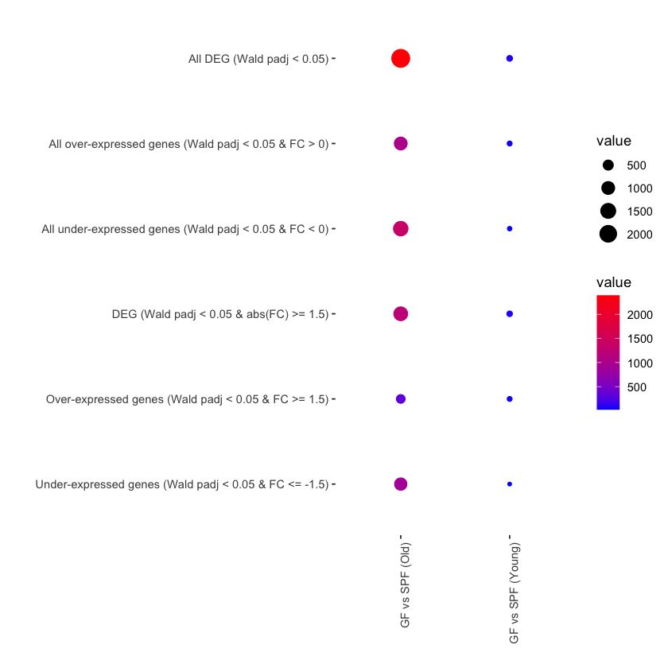

A tibble: 6 × 2

|  | GF vs SPF (Young) <int> | GF vs SPF (Old) <int> |
| --- | --- | --- |
| All DEG (Wald padj < 0.05) | 73 | 2391 |
| All over-expressed genes (Wald padj < 0.05 & FC > 0) | 42 | 1007 |
| All under-expressed genes (Wald padj < 0.05 & FC < 0) | 31 | 1384 |
| DEG (Wald padj < 0.05 & abs(FC) >= 1.5) | 65 | 1215 |
| Over-expressed genes (Wald padj < 0.05 & FC >= 1.5) | 40 | 318 |
| Under-expressed genes (Wald padj < 0.05 & FC <= -1.5) | 25 | 897 |

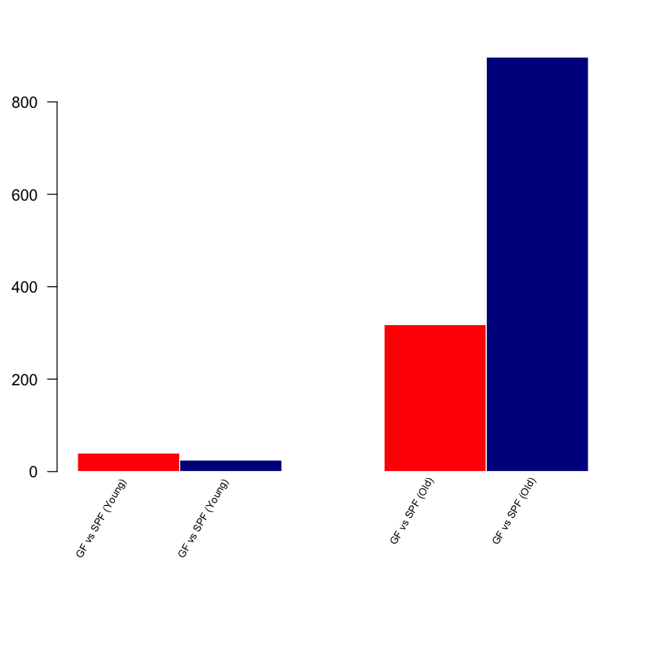

```r
deg = extract_DEG_stats(deg, dir_path)
deg$stat
```

All DEG (Wald padj < 0.05)

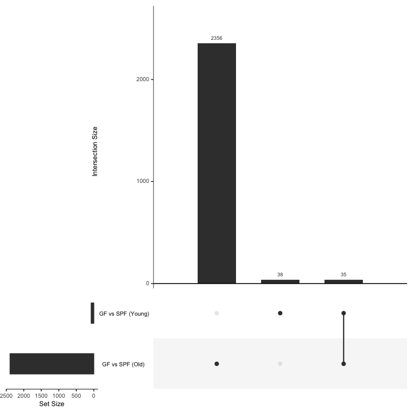

```r
plot_sign_DEG_upset(deg)
```

DEG (Wald padj < 0.05 & abs(FC) > 1.5)

**pdf:** 2

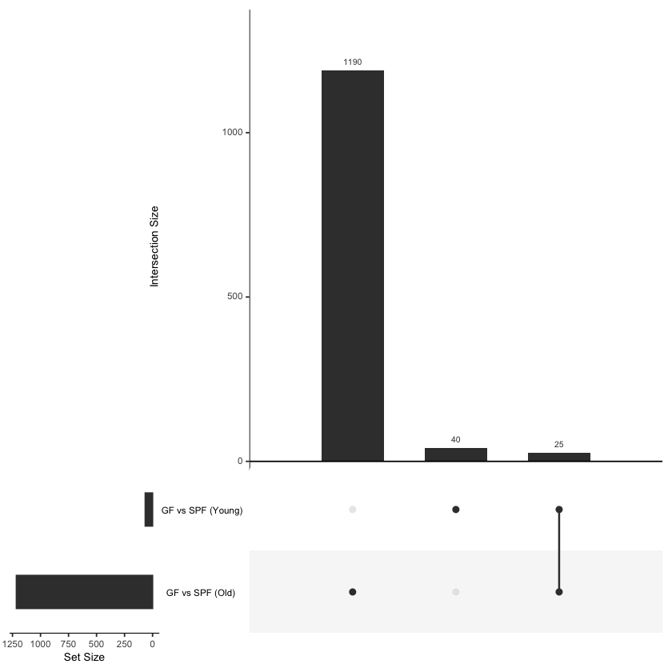

```r
pdf(paste(dir_path, "sign_FC_DEG_upset.pdf", sep=''))
plot_sign_FC_DEG_upset(deg)
dev.off()
plot_sign_FC_DEG_upset(deg)
```

# DEG (Wald padj < 0.05 & abs(FC) > 1.5)

## Log2FC

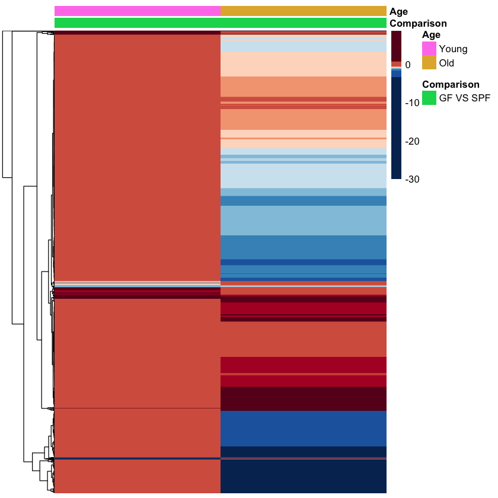

```r
data = deg$sign_fc_deg %>% select(-genes)
fc_annot = data.frame(Comparison = rep("GF VS SPF",2),
                      Age = c("Young", "Old"),
                      row.names = colnames(data))
plot_fc_heatmap(data, fc_annot)
```

## Z-score

```r
comps = list(
    "GF vs SPF (Young)" = c(metadata %>% filter(Age == "Young" & Microbiota == "SPF") %>% pull(sample),
                  metadata %>% filter(Age == "Young" & Microbiota == "GF") %>% pull(sample)),
    "GF vs SPF (Old)" = c(metadata %>% filter(Age == "Old" & Microbiota == "SPF") %>% pull(sample),
                  metadata %>% filter(Age == "Old" & Microbiota == "GF") %>% pull(sample))
)
comps
```

**$`GF vs SPF (Young)`**

1. 'SPF_8w_M_2_2'

2. 'SPF_8w_M_3_2'

3. 'SPF_8w_M_4_2'

4. 'GF_8w_M_1_2'

5. 'GF_8w_M_3_2'

6. 'GF_8w_M_4_2'

**$`GF vs SPF (Old)`**

1. 'SPF_104w_M_1_2'

2. 'SPF_104w_M_10_2'

3. 'SPF_104w_M_11_2'

4. 'SPF_104w_M_12_2'

5. 'SPF_104w_M_13_2'

6. 'SPF_104w_M_14_2'

7. 'SPF_104w_M_2_2'

8. 'SPF_104w_M_4_2'

9. 'SPF_104w_M_5_2'

10. 'SPF_104w_M_6_2'

11. 'SPF_104w_M_7_2'

12. 'SPF_104w_M_8_2'

13. 'SPF_104w_M_9_2'

14. 'GF_104w_M_1_2'

15. 'GF_104w_M_2_2'

16. 'GF_104w_M_3_2'

17. 'GF_104w_M_4_2'

18. 'GF_104w_M_5_2'

### Column order: age - microbiota

**pdf:** 3

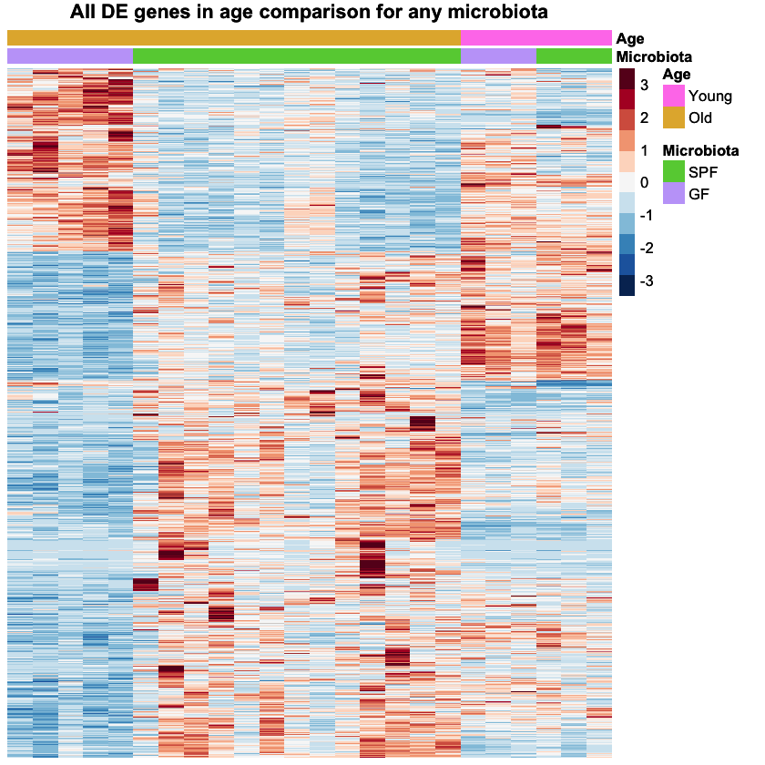

```r
plot_z_score_heatmap(z_scores,
                     deg$sign_fc_deg$genes,
                     col_order$am,
                     annot_col$am,
                     "All DE genes in age comparison for any microbiota",
                     col_order$am)
pdf(paste(dir_path, "z_score_am.pdf", sep=''))
plot_z_score_heatmap(z_scores,
                     deg$sign_fc_deg$genes,
                     col_order$am,
                     annot_col$am,
                     "All DE genes in age comparison for any microbiota",
                     col_order$am)
dev.off()
```

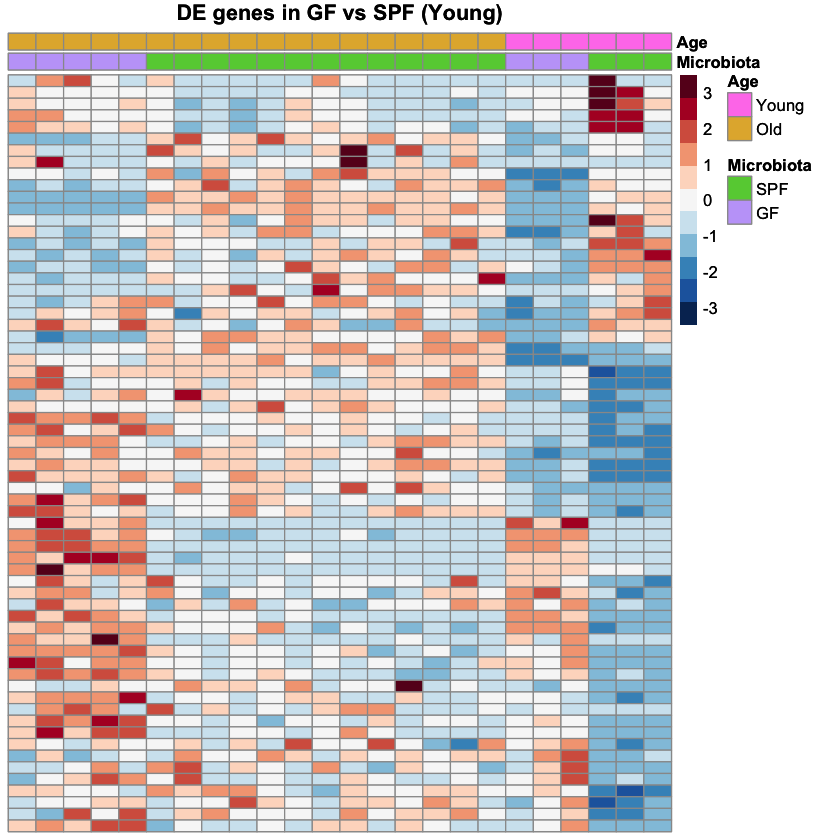

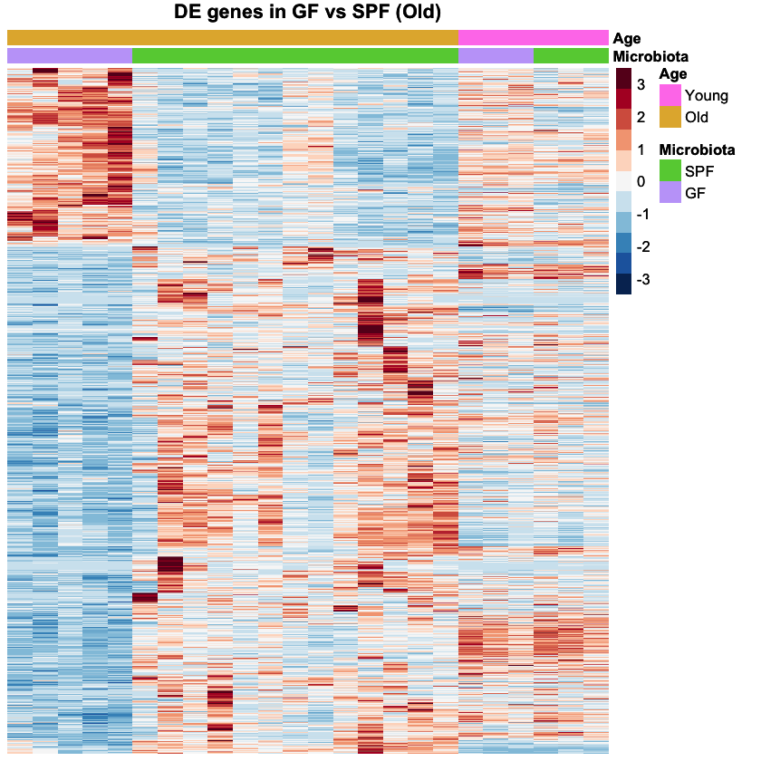

```r
for(comp in names(comps)){
    plot_z_score_heatmap(z_scores,
        deg$sign_fc_deg %>% filter(!is.na((!!as.name(comp)))) %>% pull(genes),
        col_order$am,
        annot_col$am,
        paste("DE genes in", comp),
        comps[[comp]])
}
```

### Column order: microbiota - age

**pdf:** 3

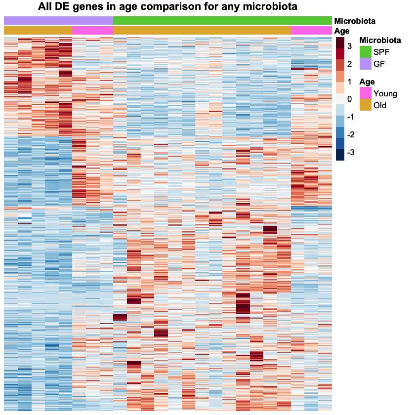

```r
plot_z_score_heatmap(z_scores,
                     deg$sign_fc_deg$genes,
                     col_order$ma,
                     annot_col$ma,
                     "All DE genes in age comparison for any microbiota",
                     col_order$ma)
pdf(paste(dir_path, "z_score_ma.pdf", sep=''))
plot_z_score_heatmap(z_scores,
                     deg$sign_fc_deg$genes,
                     col_order$ma,
                     annot_col$ma,
                     "All DE genes in age comparison for any microbiota",
                     col_order$ma)
dev.off()
```

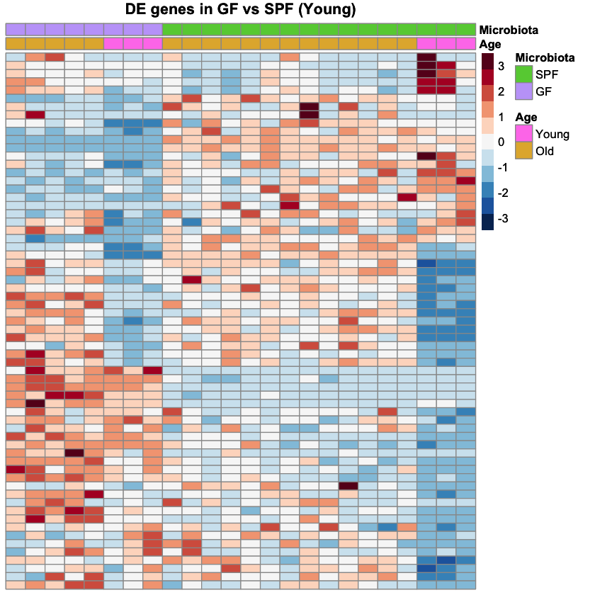

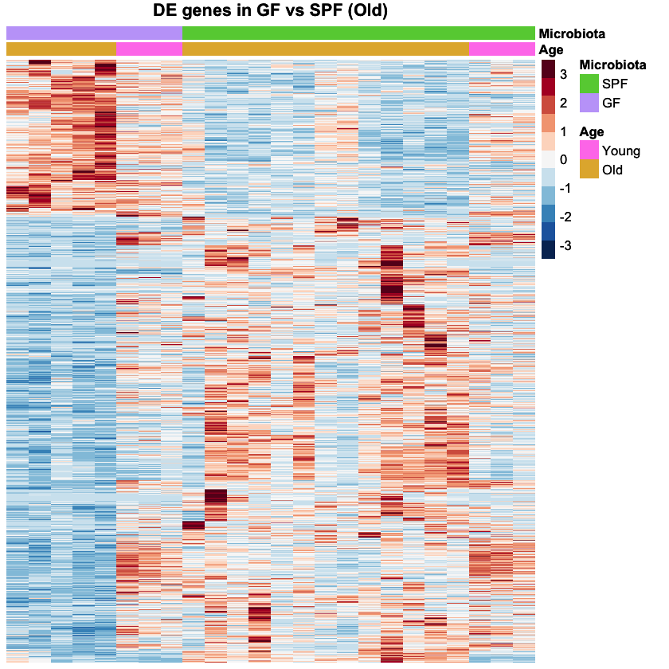

```r
for(comp in names(comps)){
    plot_z_score_heatmap(z_scores,
        deg$sign_fc_deg %>% filter(!is.na((!!as.name(comp)))) %>% pull(genes),
        col_order$ma,
        annot_col$ma,
        paste("DE genes in", comp),
        comps[[comp]])
}
```

# Co-expression (WGCNA)

## Z-score in modules

```r
comps = names(comps)
```

### Column order: age - microbiota

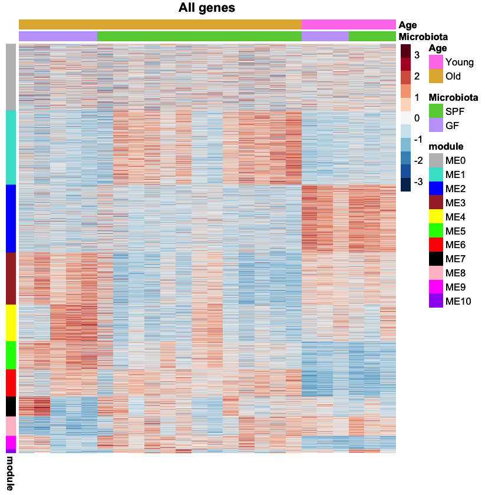

```r
plot_z_score_heatmap_with_modules(z_scores,
                                  rownames(z_scores),
                                  col_order$am,
                                  annot_col$am,
                                  genes_in_modules,
                                  "All genes")
```

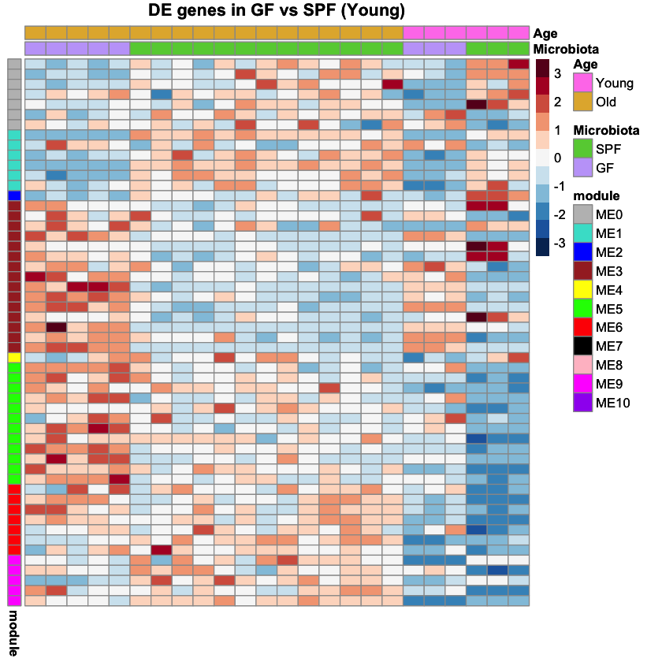

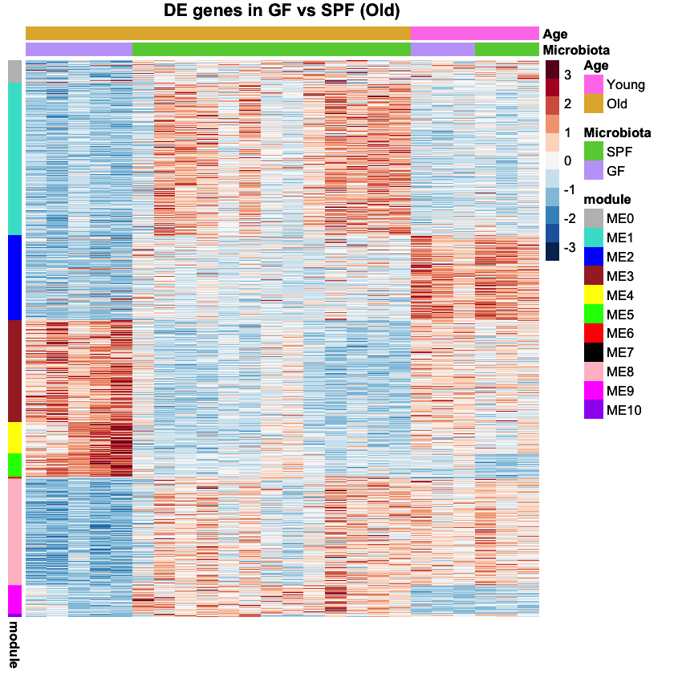

```r
for(comp in comps){
    plot_z_score_heatmap_with_modules(z_scores,
        deg$sign_fc_deg %>% filter(!is.na((!!as.name(comp)))) %>% pull(genes),
        col_order$am,
        annot_col$am,
        genes_in_modules,
        paste("DE genes in", comp))
}
```

### Column order: microbiota - age

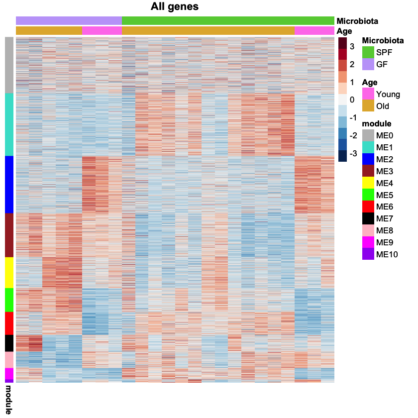

```r
plot_z_score_heatmap_with_modules(z_scores,
    rownames(z_scores),
    col_order$ma,
    annot_col$ma,
    genes_in_modules,
    "All genes")
```

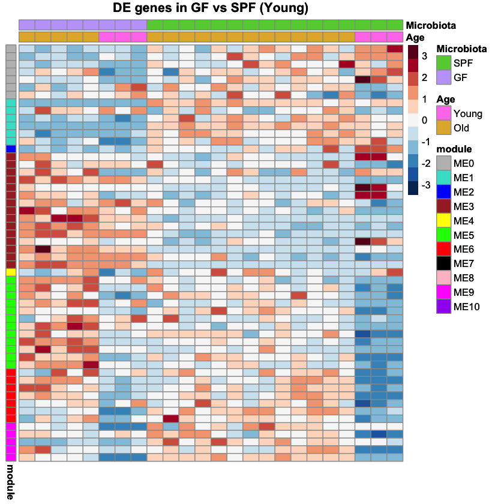

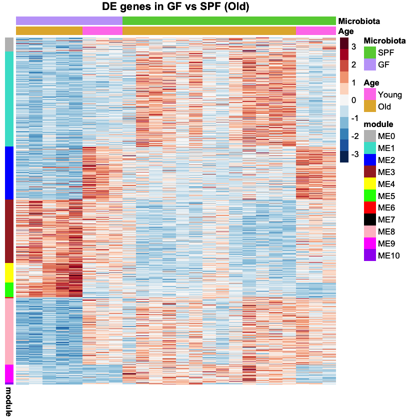

```r
for(comp in comps){
    plot_z_score_heatmap_with_modules(z_scores,
        deg$sign_fc_deg %>% filter(!is.na((!!as.name(comp)))) %>% pull(genes),
        col_order$ma,
        annot_col$ma,
        genes_in_modules,
        paste("DE genes in", comp))
}
```

## Genes in modules

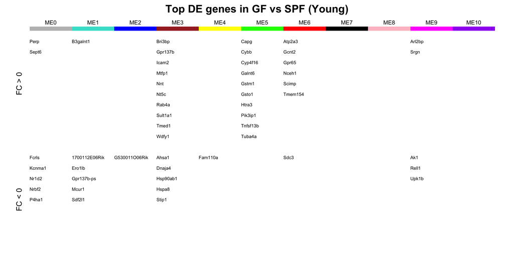

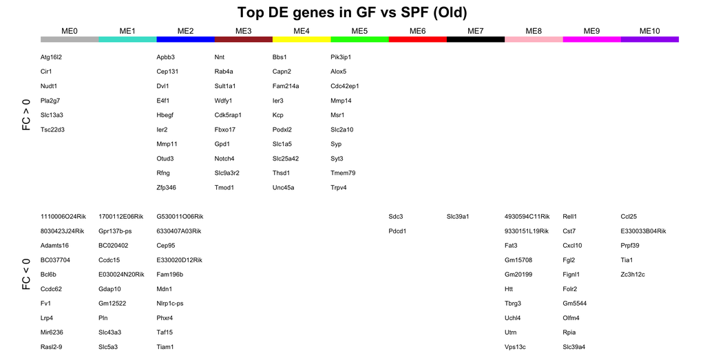

```r
for(comp in comps){
    plot_top_deg_in_modules(deg$sign_fc_deg, comp, genes_in_modules)
}
options(repr.plot.width=7, repr.plot.height=7)
```

# Enrichment analysis

```r
deg = fit_proba_weighting_function(deg, gene_length)
```

## GO analysis

```r
deg = extract_GO_terms(deg, dir_path, "../../data/go_term_to_exclude.csv")
```

### Biological process

Dot-plot with the 10 most significant p-values for the different comparison

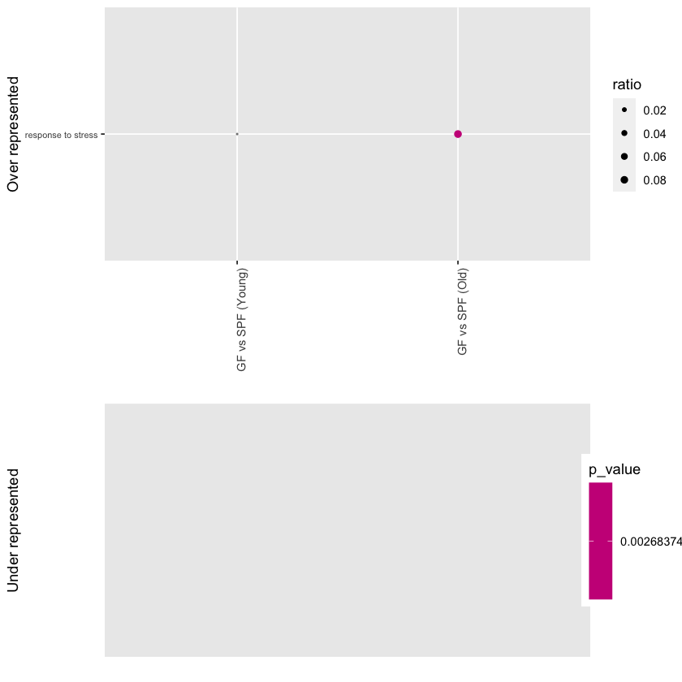

```r
plot_top_go(deg, "BP", 10)
```

### Cellular components

Dot-plot with the 10 most significant p-values for the different comparison

[figure not shown]

```r
plot_top_go(deg, "CC", 10)
```

### Molecular functions

Dot-plot with the 10 most significant p-values for the different comparison

[figure not shown]

```r
plot_top_go(deg, "MF", 10)
```

## KEGG pathways

```r
deg = extract_KEGG_pathways(deg, dir_path)
```

```r
plot_kegg_pathways(deg$KEGG$over$category,
                   deg$sign_fc_deg,
                   paste(dir_path, '/kegg/over_repr_kegg/', sep=''))
```

```r
plot_kegg_pathways(deg$under_represented_KEGG[,"category"],
                   deg$fc_deg,
                   paste(dir_path, '/kegg/under_repr_kegg/', sep=''))
```

# Citations

```r
citation("pheatmap")
```

```
  Raivo Kolde (2019). pheatmap: Pretty Heatmaps. R package version
  1.0.12. https://CRAN.R-project.org/package=pheatmap

A BibTeX entry for LaTeX users is

  @Manual{,
    title = {pheatmap: Pretty Heatmaps},
    author = {Raivo Kolde},
    year = {2019},
    note = {R package version 1.0.12},
    url = {https://CRAN.R-project.org/package=pheatmap},
  }

ATTENTION: This citation information has been auto-generated from the
package DESCRIPTION file and may need manual editing, see
‘help("citation")’.
```

```r
citation("pathview")
```

```
  Luo, W. and Brouwer C., Pathview: an R/Bioconductor package for
  pathway-based data integration and visualization. Bioinformatics,
  2013, 29(14): 1830-1831, doi: 10.1093/bioinformatics/btt285

A BibTeX entry for LaTeX users is

  @Article{,
    author = {{Luo} and {Weijun} and {Brouwer} and {Cory}},
    title = {Pathview: an R/Bioconductor package for pathway-based data integration and visualization},
    journal = {Bioinformatics},
    year = {2013},
    doi = {10.1093/bioinformatics/btt285},
    volume = {29},
    number = {14},
    pages = {1830-1831},
  }

This free open-source software implements academic research by the
authors. Its development took a large amount of extra time and effort.
If you use it, please support the project by citing the listed journal
articles.
```